# GAMMs LabPhon 18

Jalal Al-Tamimi

Newcastle University

6 June 2018

# 1 Loading packages

```r
library(ggplot2);library(mgcv);library(itsadug);library(tidyverse);library(gganimate)
```

# 2 Demo Linear Model vs GAM

In this demo, data obtained from a Jordanian Arabic speaker producing the word /du:d/ “worm” is used. F2 frequencies obtained at 5 ms interval from onset to midpoint of the vowel are used. Let’s plot the F2 frequencies by interval number. The second plot displays a linear regression line superimposed on the plot. As can be seen, the linear regression line is not able to cope with the curviness of the data, and is unable to cope with it. The third plot superimposes a spline obtained from a GAM model.

```r
demoGAMProd <- read.csv("dataProd_duud.csv")
head(demoGAMProd)
```

|  | IntervalsN | F2 |
| --- | --- | --- |
| 1 | 0 | 1721.132 |
| 2 | 1 | 1640.935 |
| 3 | 2 | 1566.011 |
| 4 | 3 | 1506.776 |
| 5 | 4 | 1426.349 |
| 6 | 5 | 1373.035 |

```r
ggplot.demo1 <- ggplot(demoGAMProd,aes(x=IntervalsN,y=F2))+
                geom_point()+theme_bw(base_size = 20)+coord_cartesian(ylim=c(600,1800))+
                labs(y = "F2 Hz", x = "Intervals number")
ggplot.demo1
ggplot.demo2 <- ggplot(demoGAMProd,aes(x=IntervalsN,y=F2))+
  geom_point()+theme_bw(base_size = 20)+coord_cartesian(ylim=c(600,1800))+
  labs(y = "F2 Hz", x = "Intervals number")+geom_smooth(method = lm, se=F)
ggplot.demo2
```

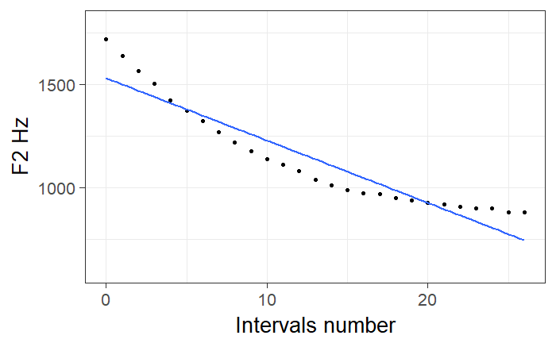

[figure not shown]

```r
ggplot.demo3 <- ggplot(demoGAMProd,aes(x=IntervalsN,y=predict(bam(F2 ~ s(IntervalsN, bs="cr"), data = demoGAMProd))))+
  geom_point()+theme_bw(base_size = 20)+coord_cartesian(ylim=c(600,1800))+
  labs(y = "F2 Hz", x = "Intervals number")+geom_smooth(method = lm, formula = y ~ splines::bs(x, 3),se=F)
ggplot.demo3
```

[output not shown]

# 3 Actual data analyses

This data is obtained from a single speaker producing various consonants in the frame VCV, with V = symmetric /i: a: u:/ (=vowel) and C is one of 17 consonants put into five contexts “plain”, “velar”, “uvular”, “pharyngealised” and “pharyngeal” (=context). The data is from Ultrasound Tongue Imaging. Tongue contours were obtained at the consonant onset, midpoint and offset (=time). A total of 51 words (=word) were obtained and these were repeated 3 times. Tongue splines were extracted with X-Y coordinates (=y outcome). 42 Fan positions (=Fan) were extracted and these are used as a normalisation between contexts. The outcome is y, the predictors are Fan, time, context and vowel, and the random factor is word.

## 3.1 Creating new variables

Before running the actual GAM model on the data, we need to:

```r
pharDF <- read.csv("resultsFull.c_NoRelNoz.csv")
str(pharDF)
```

```
'data.frame':   18900 obs. of  23 variables:
 $ X.1                        : int  1 2 3 4 5 6 7 8 9 10 ...
 $ ID                         : int  1 2 3 7 8 9 10 11 12 13 ...
 $ Client.Surname             : chr  "Sara" "Sara" "Sara" "Sara" ...
 $ Time.of.sample.in.recording: num  3.84 5.37 2.37 5.3 2.26 ...
 $ Prompt                     : chr  "2aataa.... 2aataa.... 2aataa.... 2aattaa.... 2aattaa.... 2aattaa" "2aataa.... 2aataa.... 2aataa.... 2aattaa.... 2aattaa.... 2aattaa" "2aataa.... 2aataa.... 2aataa.... 2aattaa.... 2aattaa.... 2aattaa" "2aataa.... 2aataa.... 2aataa.... 2aattaa.... 2aattaa.... 2aat…
 $ word                       : chr  "2aataa" "2aataa" "2aataa" "2aataa" ...
 $ context                    : chr  "plain" "plain" "plain" "plain" ...
 $ consonant                  : chr  "t" "t" "t" "t" ...
 $ consType                   : chr  "plosive" "plosive" "plosive" "plosive" ...
 $ vowel                      : chr  "aa" "aa" "aa" "aa" ...
 $ labelNew                   : chr  "CL_Mid" "CL_Mid" "CL_Mid" "CL_Ons" ...
 $ label                      : chr  "CL_Mid" "CL_Mid" "CL_Mid" "CL_Ons" ...
 $ repetition                 : int  2 3 1 3 1 2 3 1 2 2 ...
 $ Fan                        : int  1 1 1 1 1 1 1 1 1 1 ...
 $ x                          : num  18.8 18.9 21.5 19.1 17.7 ...
 $ y                          : num  15.6 15.6 14.1 15.5 16.3 ...
 $ vowel2                     : chr  "aː" "aː" "aː" "aː" ...
 $ labelNew2                  : int  2 2 2 1 1 1 3 3 3 2 ...
 $ context.ord                : chr  "plain" "plain" "plain" "plain" ...
 $ vowel.ord                  : chr  "aa" "aa" "aa" "aa" ...
 $ fan_line                   : int  1 1 1 1 1 1 1 1 1 1 ...
 $ X                          : num  18.8 18.9 21.5 19.1 17.7 ...
 $ Y                          : num  15.6 15.6 14.1 15.5 16.3 ...
```

```r
levels(pharDF$context)
```

```r
pharDF$context <- factor(pharDF$context,
                                levels = c("plain","velar","uvular","pharyngealised","pharyngeal"))
levels(pharDF$vowel)
```

```r
pharDF$vowel <- factor(pharDF$vowel,
                              levels = c("ii","aa","uu"))
levels(pharDF$labelNew)
```

```r
pharDF$labelNew <- factor(pharDF$labelNew,
                                 levels = c("CL_Ons","CL_Mid","CL_Off"))


pharDF$ID <- as.numeric(pharDF$ID)
pharDF$Fan <- as.numeric(pharDF$Fan)
pharDF$time <- pharDF$labelNew2


pharDF$context.ord <- as.ordered(pharDF$context)
contrasts(pharDF$context.ord) <- "contr.treatment"

pharDF$vowel.ord <- as.ordered(pharDF$vowel)
contrasts(pharDF$vowel.ord) <- "contr.treatment"

## to find autocorrelation in the data. Rearrange dataframe and add a variable "start" to indicate
## when Fan == 1
pharDF <- arrange(pharDF, time, ID, Fan)
pharDF$start <- pharDF$Fan==1
```

## 3.2 Visualising the data

Before running anything, we start by visualising the data and use an animated figure

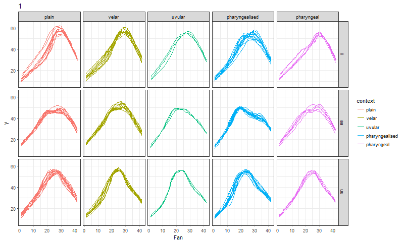

```r
pl <- ggplot(pharDF, aes(x=Fan, y=y, col=context, frame=time)) +
  facet_grid(vowel ~ context) +
  geom_line(aes(group=ID))+theme_bw()
gganimate(pl, ani.width=800, height=300)
```

## 3.3 Running our first GAM model

This is our first GAM model. This will be used to find the level of autocorrelation in the data. Our model has double non-linear predictors (fan and time), two factor predictors (context and vowel) and one random effect (word). Interactions between fan and time are used. In addition, by context*vowel interaction is added to account for the two-way interaction with respect to each of fan and time. The function itsadug::acf_resid is used, and we display the level of autocorrelation for each of the “Fan”, the “time”, the “context”, the “vowel” finally the “word”

```r
phar.gam.noAR <- bam(y ~ context.ord*vowel.ord +
                        ## 1d smooths
                        s(Fan, bs="cr", k=10) +
                        s(time, bs="cr", k=3) +
                        ## 1d smooths * factors
                        s(Fan, k=10, bs="cr", by=context.ord) +
                        s(Fan, k=10, bs="cr", by=vowel.ord) +
                        s(Fan, k=10, bs="cr", by=context.ord:vowel.ord) +
                        s(time, k=3, bs="cr", by=context.ord) +
                        s(time, k=3, bs="cr", by=vowel.ord) +
                        s(time, k=3, bs="cr", by=context.ord:vowel.ord) +
                        ## 2d smooths
                        ti(Fan, time, bs="cr", k=c(10,3))+
                        ## 2d smooths * factors
                        ti(Fan, time, bs="cr", k=c(10,3),by=context.ord)+
                        ti(Fan, time, bs="cr", k=c(10,3),by=vowel.ord)+
                        ti(Fan, time, bs="cr", k=c(10,3),by=context.ord:vowel.ord)+
                        ## random smooths by word
                        s(Fan, word, bs="fs", k=10, m=1) +
                        s(time, word, bs="fs", k=3, m=1),
                        data=pharDF)
```

```r
summary(phar.gam.noAR)
```

```
Family: gaussian
Link function: identity

Formula:
y ~ context.ord * vowel.ord + s(Fan, bs = "cr", k = 10) +
    s(time, bs = "cr", k = 3) + s(Fan, k = 10, bs = "cr",
    by = context.ord) + s(Fan, k = 10, bs = "cr", by = vowel.ord) +
    s(Fan, k = 10, bs = "cr", by = context.ord:vowel.ord) +
    s(time, k = 3, bs = "cr", by = context.ord) + s(time,
    k = 3, bs = "cr", by = vowel.ord) + s(time, k = 3,
    bs = "cr", by = context.ord:vowel.ord) + ti(Fan, time,
    bs = "cr", k = c(10, 3)) + ti(Fan, time, bs = "cr",
    k = c(10, 3), by = context.ord) + ti(Fan, time, bs = "cr",
    k = c(10, 3), by = vowel.ord) + ti(Fan, time, bs = "cr",
    k = c(10, 3), by = context.ord:vowel.ord) + s(Fan, word,
    bs = "fs", k = 10, m = 1) + s(time, word, bs = "fs",
    k = 3, m = 1)

Parametric coefficients:
                                      Estimate Std. Error t value Pr(>|t|)
(Intercept)                            35.8171     0.6348  56.422   <2e-16 ***
context.ordvelar                        1.9427     0.8882   2.187   0.0287 *
context.orduvular                       1.8558     1.2923   1.436   0.1510
context.ordpharyngealised               0.7096     0.8366   0.848   0.3964
context.ordpharyngeal                   0.7807     1.0983   0.711   0.4772
vowel.ordaa                             0.7598     0.8454   0.899   0.3688
vowel.orduu                             0.8967     0.8357   1.073   0.2833
context.ordvelar:vowel.ordaa           -0.9334     1.2093  -0.772   0.4402
context.orduvular:vowel.ordaa          -2.2185     1.6007  -1.386   0.1658
context.ordpharyngealised:vowel.ordaa  -1.3093     1.1544  -1.134   0.2567
context.ordpharyngeal:vowel.ordaa       0.2187     1.4674   0.149   0.8815
context.ordvelar:vowel.orduu           -2.3741     1.2207  -1.945   0.0518 .
context.orduvular:vowel.orduu          -2.6085     1.8942  -1.377   0.1685
context.ordpharyngealised:vowel.orduu  -1.8392     1.0893  -1.688   0.0914 .
context.ordpharyngeal:vowel.orduu      -1.0306     1.4959  -0.689   0.4909
---
Signif. codes:  0 ‘***’ 0.001 ‘**’ 0.01 ‘*’ 0.05 ‘.’ 0.1 ‘ ’ 1

Approximate significance of smooth terms:
                                                          edf    Ref.df      F
```

[output cut: 128 more lines]

```
ti(Fan,time):context.ord:vowel.orduvular:uu         0.000240 ***
ti(Fan,time):context.ord:vowel.ordpharyngealised:ii  < 2e-16 ***
ti(Fan,time):context.ord:vowel.ordpharyngealised:aa 0.829029
ti(Fan,time):context.ord:vowel.ordpharyngealised:uu 0.610342
ti(Fan,time):context.ord:vowel.ordpharyngeal:ii      < 2e-16 ***
ti(Fan,time):context.ord:vowel.ordpharyngeal:aa     0.007720 **
ti(Fan,time):context.ord:vowel.ordpharyngeal:uu      < 2e-16 ***
s(Fan,word)                                          < 2e-16 ***
s(time,word)                                         < 2e-16 ***
---
Signif. codes:  0 ‘***’ 0.001 ‘**’ 0.01 ‘*’ 0.05 ‘.’ 0.1 ‘ ’ 1

Rank: 1282/1303
R-sq.(adj) =  0.986   Deviance explained = 98.6%
fREML =  35503  Scale est. = 2.207     n = 18900
```

```r
rho_est <- start_value_rho(phar.gam.noAR)
rho_est
```

```
[1] 0.9417107
```

### 3.3.1 ACF first GAM

#### 3.3.1.1 ACF by Fan

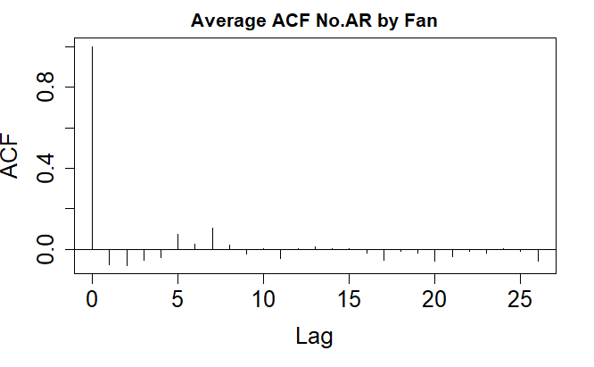

```r
acf_resid(phar.gam.noAR,split_pred=list(pharDF$Fan),main = "Average ACF No.AR by Fan",cex.lab=1.5,cex.axis=1.5)
```

#### 3.3.1.2 ACF by Time

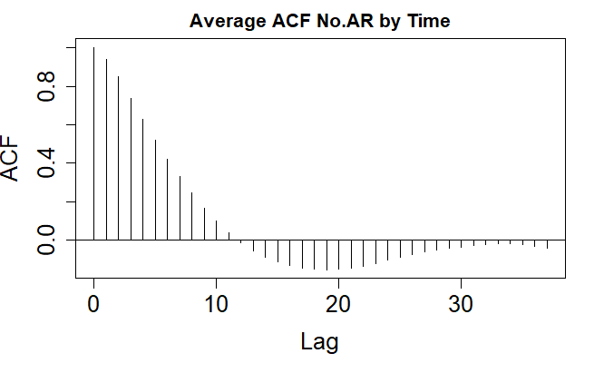

```r
acf_resid(phar.gam.noAR,split_pred=list(pharDF$time),main = "Average ACF No.AR by Time",cex.lab=1.5,cex.axis=1.5)
```

#### 3.3.1.3 ACF by Context

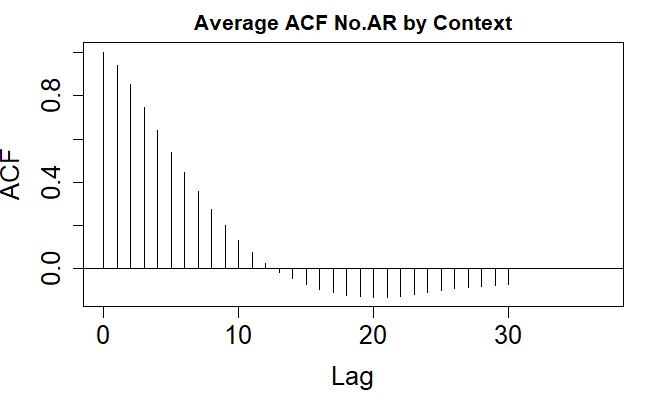

```r
acf_resid(phar.gam.noAR,split_pred=list(pharDF$context.ord),main = "Average ACF No.AR by Context",cex.lab=1.5,cex.axis=1.5)
```

#### 3.3.1.4 ACF by Vowel

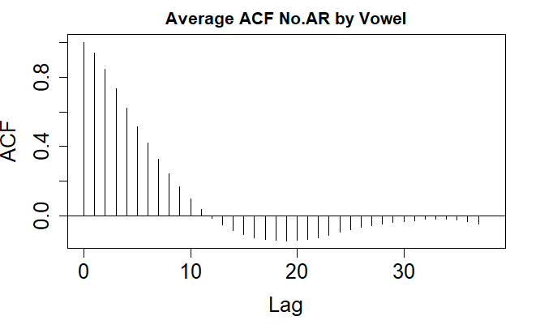

```r
acf_resid(phar.gam.noAR,split_pred=list(pharDF$vowel.ord),main = "Average ACF No.AR by Vowel",cex.lab=1.5,cex.axis=1.5)
```

#### 3.3.1.5 ACF by Word

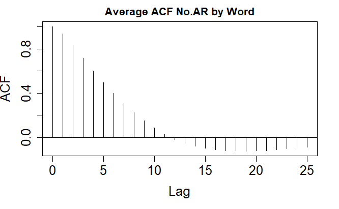

```r
acf_resid(phar.gam.noAR,split_pred=list(pharDF$word),main = "Average ACF No.AR by Word",cex.lab=1.5,cex.axis=1.5)
```

## 3.4 Running our second Autoregressive GAM

Our second GAM model is identical to the first, but takes into account the autocorrelation. By including AR.start and rho, we are using information obtained from original model to account for the autocorrelation

```r
phar.gam.AR <- bam(y ~ context.ord*vowel.ord +
                       ## 1d smooths
                       s(Fan, bs="cr", k=10) +
                       s(time, bs="cr", k=3) +
                       ## 1d smooths * factors
                       s(Fan, k=10, bs="cr", by=context.ord) +
                       s(Fan, k=10, bs="cr", by=vowel.ord) +
                       s(Fan, k=10, bs="cr", by=context.ord:vowel.ord) +
                       s(time, k=3, bs="cr", by=context.ord) +
                       s(time, k=3, bs="cr", by=vowel.ord) +
                       s(time, k=3, bs="cr", by=context.ord:vowel.ord) +
                       ## 2d smooths
                       ti(Fan, time, bs="cr", k=c(10,3))+
                       ## 2d smooths * factors
                       ti(Fan, time, bs="cr", k=c(10,3),by=context.ord)+
                       ti(Fan, time, bs="cr", k=c(10,3),by=vowel.ord)+
                       ti(Fan, time, bs="cr", k=c(10,3),by=context.ord:vowel.ord)+
                       ## random smooths by word
                       s(Fan, word, bs="fs", k=10, m=1) +
                       s(time, word, bs="fs", k=3, m=1),
                       data=pharDF,
                       AR.start=pharDF$start, rho=rho_est)
```

```r
summary(phar.gam.AR)
```

```
Family: gaussian
Link function: identity

Formula:
y ~ context.ord * vowel.ord + s(Fan, bs = "cr", k = 10) +
    s(time, bs = "cr", k = 3) + s(Fan, k = 10, bs = "cr",
    by = context.ord) + s(Fan, k = 10, bs = "cr", by = vowel.ord) +
    s(Fan, k = 10, bs = "cr", by = context.ord:vowel.ord) +
    s(time, k = 3, bs = "cr", by = context.ord) + s(time,
    k = 3, bs = "cr", by = vowel.ord) + s(time, k = 3,
    bs = "cr", by = context.ord:vowel.ord) + ti(Fan, time,
    bs = "cr", k = c(10, 3)) + ti(Fan, time, bs = "cr",
    k = c(10, 3), by = context.ord) + ti(Fan, time, bs = "cr",
    k = c(10, 3), by = vowel.ord) + ti(Fan, time, bs = "cr",
    k = c(10, 3), by = context.ord:vowel.ord) + s(Fan, word,
    bs = "fs", k = 10, m = 1) + s(time, word, bs = "fs",
    k = 3, m = 1)

Parametric coefficients:
                                      Estimate Std. Error t value Pr(>|t|)
(Intercept)                            35.9560     0.6230  57.711   <2e-16 ***
context.ordvelar                        1.8550     0.8688   2.135   0.0328 *
context.orduvular                       2.3446     1.2999   1.804   0.0713 .
context.ordpharyngealised               0.5531     0.8208   0.674   0.5004
context.ordpharyngeal                   0.4110     1.0741   0.383   0.7020
vowel.ordaa                             0.8223     0.7951   1.034   0.3011
vowel.orduu                             0.7214     0.8147   0.886   0.3759
context.ordvelar:vowel.ordaa           -1.0865     1.1455  -0.949   0.3429
context.orduvular:vowel.ordaa          -3.5099     1.6458  -2.133   0.0330 *
context.ordpharyngealised:vowel.ordaa  -1.4259     1.1032  -1.293   0.1962
context.ordpharyngeal:vowel.ordaa      -0.4642     1.2658  -0.367   0.7138
context.ordvelar:vowel.orduu           -2.1728     1.1932  -1.821   0.0686 .
context.orduvular:vowel.orduu          -2.8293     1.6414  -1.724   0.0848 .
context.ordpharyngealised:vowel.orduu  -1.7135     1.0680  -1.604   0.1086
context.ordpharyngeal:vowel.orduu      -0.5365     1.4511  -0.370   0.7116
---
Signif. codes:  0 ‘***’ 0.001 ‘**’ 0.01 ‘*’ 0.05 ‘.’ 0.1 ‘ ’ 1

Approximate significance of smooth terms:
                                                          edf    Ref.df       F
```

[output cut: 128 more lines]

```
ti(Fan,time):context.ord:vowel.orduvular:uu         0.296132
ti(Fan,time):context.ord:vowel.ordpharyngealised:ii  < 2e-16 ***
ti(Fan,time):context.ord:vowel.ordpharyngealised:aa 0.706603
ti(Fan,time):context.ord:vowel.ordpharyngealised:uu 0.756240
ti(Fan,time):context.ord:vowel.ordpharyngeal:ii     4.62e-09 ***
ti(Fan,time):context.ord:vowel.ordpharyngeal:aa     0.012872 *
ti(Fan,time):context.ord:vowel.ordpharyngeal:uu     2.36e-12 ***
s(Fan,word)                                          < 2e-16 ***
s(time,word)                                         < 2e-16 ***
---
Signif. codes:  0 ‘***’ 0.001 ‘**’ 0.01 ‘*’ 0.05 ‘.’ 0.1 ‘ ’ 1

Rank: 1282/1303
R-sq.(adj) =  0.984   Deviance explained = 98.5%
fREML =  12790  Scale est. = 1.6966    n = 18900
```

### 3.4.1 ACF second GAM

The following five plots show (in the same order as above) the autocorrelation in the residuals. As can be seen, for all five plots, the levels of autocorrelations in the residuals are reduced massively. We have now more confidence in our estimates, and can continue work

#### 3.4.1.1 ACF by Fan

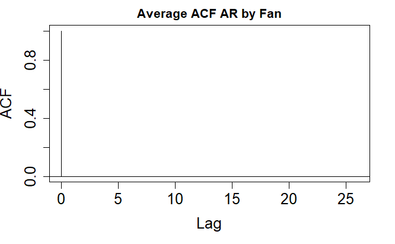

```r
acf_resid(phar.gam.AR,split_pred=list(pharDF$Fan),main = "Average ACF AR by Fan",cex.lab=1.5,cex.axis=1.5)
```

#### 3.4.1.2 ACF by Time

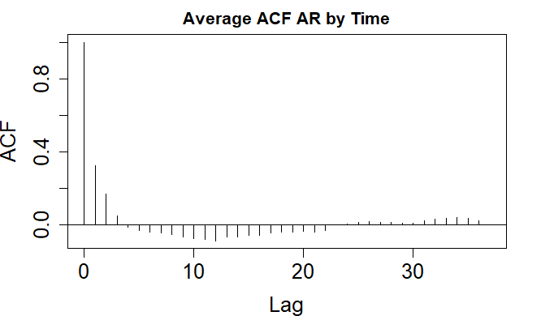

```r
acf_resid(phar.gam.AR,split_pred=list(pharDF$time),main = "Average ACF AR by Time",cex.lab=1.5,cex.axis=1.5)
```

#### 3.4.1.3 ACF by Context

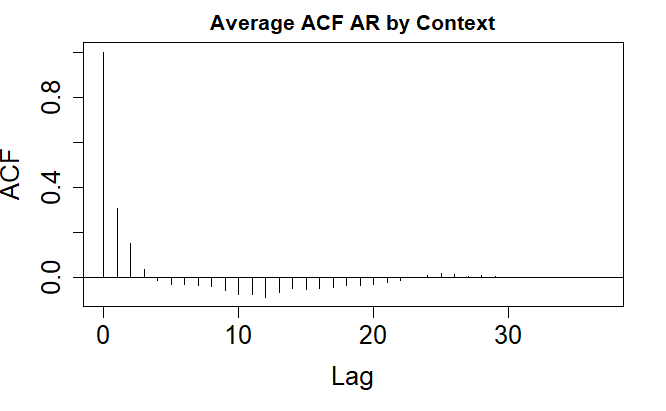

```r
acf_resid(phar.gam.AR,split_pred=list(pharDF$context.ord),main = "Average ACF AR by Context",cex.lab=1.5,cex.axis=1.5)
```

#### 3.4.1.4 ACF by Vowel

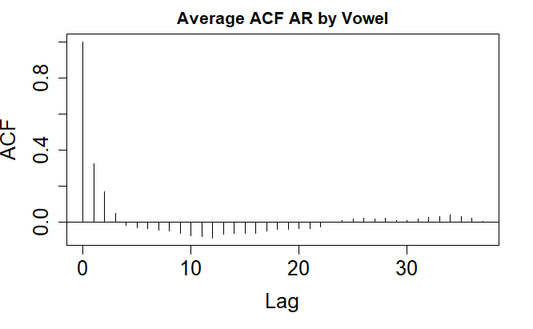

```r
acf_resid(phar.gam.AR,split_pred=list(pharDF$vowel.ord),main = "Average ACF AR by Vowel",cex.lab=1.5,cex.axis=1.5)
```

#### 3.4.1.5 ACF by Word

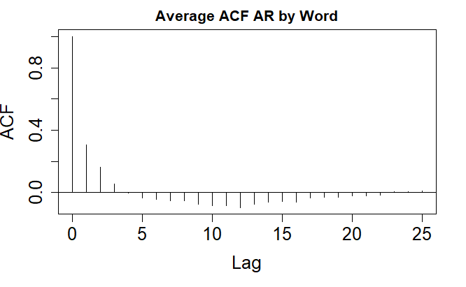

```r
acf_resid(phar.gam.AR,split_pred=list(pharDF$word),main = "Average ACF AR by Word",cex.lab=1.5,cex.axis=1.5)
```

## 3.5 Significance testing second Autoregressive GAM

To test for significance of context, we run a model with a ML as method and evaluate significance through a maximum likelihood estimate.

### 3.5.1 Models

We ran three models

1. A full model with all predictors (phar.gam.AR.ML)
2. A reduced model without any terms associated with the predictor “context” (phar.gam.AR.ML.Min.Context)
3. An intercept only model (=Null) without any terms associated with the predictor “vowel” (phar.gam.AR.ML.Min.ContextAndVowel)

```r
phar.gam.AR.ML <- bam(y ~ context.ord*vowel.ord +
                           # 1d smooths
                           s(Fan, bs="cr",k=10) +
                           s(time, bs="cr", k=3) +
                           # 1d smooth * factor
                           s(Fan, k=10, bs="cr", by=context.ord) +
                           s(Fan, k=10, bs="cr", by=vowel.ord) +
                           s(Fan, k=10, bs="cr", by=context.ord:vowel.ord) +
                           s(time, k=3, bs="cr", by=context.ord) +
                           s(time, k=3, bs="cr", by=vowel.ord) +
                           s(time, k=3, bs="cr", by=context.ord:vowel.ord) +
                           # 2d smooth
                           ti(Fan, time, bs="cr", k=c(10,3))+
                           ti(Fan, time, bs="cr", k=c(10,3),by=context.ord)+
                           ti(Fan, time, bs="cr", k=c(10,3),by=vowel.ord)+
                           ti(Fan, time, bs="cr", k=c(10,3),by=context.ord:vowel.ord)+
                           # random smooths by word
                           s(Fan, word, bs="fs", k=10, m=1) +
                           s(time, word, bs="fs", k=3, m=1),
                           data=pharDF,
                           method="ML",
                           AR.start=pharDF$start, rho=rho_est)

phar.gam.AR.ML.Min.Context <- bam(y ~ vowel.ord +
                                      # 1d smooths
                                      s(Fan, bs="cr",k=10) +
                                      s(time, bs="cr", k=3) +
                                      # 1d smooth * factor
                                      ##s(Fan, k=10, bs="cr", by=context.ord) +
                                      s(Fan, k=10, bs="cr", by=vowel.ord) +
                                      ##s(Fan, k=10, bs="cr", by=context.ord:vowel.ord) +
                                      ##s(time, k=3, bs="cr", by=context.ord) +
                                      s(time, k=3, bs="cr", by=vowel.ord) +
                                      ##s(time, k=3, bs="cr", by=context.ord:vowel.ord) +
                                      # 2d smooth
                                      ti(Fan, time, bs="cr", k=c(10,3))+
                                      ##ti(Fan, time, bs="cr", k=c(10,3),by=context.ord)+
                                      ###ti(Fan, time, bs="cr", k=c(10,3),by=vowel.ord)+
                                      ##ti(Fan, time, bs="cr", k=c(10,3),by=context.ord:vowel.ord)+
                                      # random smooths by word
                                      s(Fan, word, bs="fs", k=10, m=1) +
                                      s(time, word, bs="fs", k=3, m=1),
                                      data=pharDF,
                                      method="ML",
                                      AR.start=pharDF$start, rho=rho_est)


phar.gam.AR.ML.Min.ContextAndVowel <- bam(y ~ 1 +
                                    # 1d smooths
                                    s(Fan, bs="cr",k=10) +
                                    s(time, bs="cr", k=3) +
                                    # 1d smooth * factor
                                    ##s(Fan, k=10, bs="cr", by=context.ord) +
                                    ###s(Fan, k=10, bs="cr", by=vowel.ord) +
                                    ##s(Fan, k=10, bs="cr", by=context.ord:vowel.ord) +
                                    ##s(time, k=3, bs="cr", by=context.ord) +
                                    ###s(time, k=3, bs="cr", by=vowel.ord) +
                                    ##s(time, k=3, bs="cr", by=context.ord:vowel.ord) +
                                    # 2d smooth
                                    ##ti(Fan, time, bs="cr", k=c(10,3),by=context.ord)+
                                    ###ti(Fan, time, bs="cr", k=c(10,3),by=vowel.ord)+
                                    ##ti(Fan, time, bs="cr", k=c(10,3),by=context.ord:vowel.ord)+
                                    # random smooths by word
                                    s(Fan, word, bs="fs", k=10, m=1) +
                                    s(time, word, bs="fs", k=3, m=1),
                                    data=pharDF,
                                    method="ML",
                                    AR.start=pharDF$start, rho=rho_est)
```

### 3.5.2 Model comparison

Then we compare results of these models as below shown below.

#### 3.5.2.1 Effect of Context vs null

```r
compareML(phar.gam.AR.ML, phar.gam.AR.ML.Min.Context)
```

```
phar.gam.AR.ML: y ~ context.ord * vowel.ord + s(Fan, bs = "cr", k = 10) + s(time,
    bs = "cr", k = 3) + s(Fan, k = 10, bs = "cr", by = context.ord) +
    s(Fan, k = 10, bs = "cr", by = vowel.ord) + s(Fan, k = 10,
    bs = "cr", by = context.ord:vowel.ord) + s(time, k = 3, bs = "cr",
    by = context.ord) + s(time, k = 3, bs = "cr", by = vowel.ord) +
    s(time, k = 3, bs = "cr", by = context.ord:vowel.ord) + ti(Fan,
    time, bs = "cr", k = c(10, 3)) + ti(Fan, time, bs = "cr",
    k = c(10, 3), by = context.ord) + ti(Fan, time, bs = "cr",
    k = c(10, 3), by = vowel.ord) + ti(Fan, time, bs = "cr",
    k = c(10, 3), by = context.ord:vowel.ord) + s(Fan, word,
    bs = "fs", k = 10, m = 1) + s(time, word, bs = "fs", k = 3,
    m = 1)

phar.gam.AR.ML.Min.Context: y ~ vowel.ord + s(Fan, bs = "cr", k = 10) + s(time, bs = "cr",
    k = 3) + s(Fan, k = 10, bs = "cr", by = vowel.ord) + s(time,
    k = 3, bs = "cr", by = vowel.ord) + ti(Fan, time, bs = "cr",
    k = c(10, 3)) + s(Fan, word, bs = "fs", k = 10, m = 1) +
    s(time, word, bs = "fs", k = 3, m = 1)

Chi-square test of ML scores
-----
```

| Model | Score | Edf | Difference | Df | p.value | Sig. |
| --- | --- | --- | --- | --- | --- | --- |
| phar.gam.AR.ML.Min.Context | 14223.8 | 22 |  |  |  |  |
| phar.gam.AR.ML | 12844.6 | 173 | 1379.202 | 151.000 | < 2e-16 | *** |

```
AIC difference: -2716.25, model phar.gam.AR.ML has lower AIC.
```

#### 3.5.2.2 Effect of Vowel vs Null

```r
compareML(phar.gam.AR.ML,phar.gam.AR.ML.Min.ContextAndVowel)
```

```
phar.gam.AR.ML: y ~ context.ord * vowel.ord + s(Fan, bs = "cr", k = 10) + s(time,
    bs = "cr", k = 3) + s(Fan, k = 10, bs = "cr", by = context.ord) +
    s(Fan, k = 10, bs = "cr", by = vowel.ord) + s(Fan, k = 10,
    bs = "cr", by = context.ord:vowel.ord) + s(time, k = 3, bs = "cr",
    by = context.ord) + s(time, k = 3, bs = "cr", by = vowel.ord) +
    s(time, k = 3, bs = "cr", by = context.ord:vowel.ord) + ti(Fan,
    time, bs = "cr", k = c(10, 3)) + ti(Fan, time, bs = "cr",
    k = c(10, 3), by = context.ord) + ti(Fan, time, bs = "cr",
    k = c(10, 3), by = vowel.ord) + ti(Fan, time, bs = "cr",
    k = c(10, 3), by = context.ord:vowel.ord) + s(Fan, word,
    bs = "fs", k = 10, m = 1) + s(time, word, bs = "fs", k = 3,
    m = 1)

phar.gam.AR.ML.Min.ContextAndVowel: y ~ 1 + s(Fan, bs = "cr", k = 10) + s(time, bs = "cr", k = 3) +
    s(Fan, word, bs = "fs", k = 10, m = 1) + s(time, word, bs = "fs",
    k = 3, m = 1)

Chi-square test of ML scores
-----
```

| Model | Score | Edf | Difference | Df | p.value | Sig. |
| --- | --- | --- | --- | --- | --- | --- |
| phar.gam.AR.ML.Min.ContextAndVowel | 14433.16 | 9 |  |  |  |  |
| phar.gam.AR.ML | 12844.60 | 173 | 1588.559 | 164.000 | < 2e-16 | *** |

```
AIC difference: -3032.77, model phar.gam.AR.ML has lower AIC.
```

#### 3.5.2.3 Effect of Context vs Vowel

```r
compareML(phar.gam.AR.ML.Min.Context,phar.gam.AR.ML.Min.ContextAndVowel)
```

```
phar.gam.AR.ML.Min.Context: y ~ vowel.ord + s(Fan, bs = "cr", k = 10) + s(time, bs = "cr",
    k = 3) + s(Fan, k = 10, bs = "cr", by = vowel.ord) + s(time,
    k = 3, bs = "cr", by = vowel.ord) + ti(Fan, time, bs = "cr",
    k = c(10, 3)) + s(Fan, word, bs = "fs", k = 10, m = 1) +
    s(time, word, bs = "fs", k = 3, m = 1)

phar.gam.AR.ML.Min.ContextAndVowel: y ~ 1 + s(Fan, bs = "cr", k = 10) + s(time, bs = "cr", k = 3) +
    s(Fan, word, bs = "fs", k = 10, m = 1) + s(time, word, bs = "fs",
    k = 3, m = 1)

Chi-square test of ML scores
-----
```

| Model | Score | Edf | Difference | Df | p.value | Sig. |
| --- | --- | --- | --- | --- | --- | --- |
| phar.gam.AR.ML.Min.ContextAndVowel | 14433.16 | 9 |  |  |  |  |
| phar.gam.AR.ML.Min.Context | 14223.80 | 22 | 209.357 | 13.000 | < 2e-16 | *** |

```
AIC difference: -316.52, model phar.gam.AR.ML.Min.Context has lower AIC.
```

From the results above, both “context” and “vowel” are improving the model fit. “Context” is improving the model fit more than “vowel” (see 3rd comparison)

## 3.6 Visualising smooths from second Autoregressive GAM

We use the function itsadug::plot_smooth to plot the five smooths for context “plain”, “velar”, “uvular”, “pharyngealised” and “pharyngeal”, in each of the vowel contexts /i: a: u:/ at the onset, midpoint and offset.

The results show that at the midpoint and offset, the three contexts, uvular, pharyngealised and pharyngeal are different from each other: uvular has a higher tongue position (y coordinate); intermediate in pharyngealised and lower and fronted in pharyngeal. At the onset, the same pattern is see though to a lower degree in /a:/.

### 3.6.1 Vowel /i:/

#### 3.6.1.1 Onset

```r
plot_smooth(phar.gam.AR, view = "Fan",cond = list(context.ord="plain",vowel.ord="ii",time=1),col="darkmagenta",ylim = c(10,65),ylab="",xlab="",
            main="GAM smooths in /i:/ at Onset",hide.label=T,cex.axis=1.3,rm.ranef=T)
```

```
Summary:
    * context.ord : factor; set to the value(s): plain.
    * vowel.ord : factor; set to the value(s): ii.
    * Fan : numeric predictor; with 30 values ranging from 1.000000 to 42.000000.
    * time : numeric predictor; set to the value(s): 1.
    * word : factor; set to the value(s): 2aa3aa. (Might be canceled as random effect, check below.)
    * NOTE : The following random effects columns are canceled: s(Fan,word),s(time,word)
```

```r
plot_smooth(phar.gam.AR, view = "Fan",cond = list(context.ord="velar",vowel.ord="ii",time=1),col="gray70",add=TRUE,ylim = c(10,65),hide.label=T,cex.axis=1.3,rm.ranef=T)
```

```
Summary:
    * context.ord : factor; set to the value(s): velar.
    * vowel.ord : factor; set to the value(s): ii.
    * Fan : numeric predictor; with 30 values ranging from 1.000000 to 42.000000.
    * time : numeric predictor; set to the value(s): 1.
    * word : factor; set to the value(s): 2aa3aa. (Might be canceled as random effect, check below.)
    * NOTE : The following random effects columns are canceled: s(Fan,word),s(time,word)
```

```r
plot_smooth(phar.gam.AR, view = "Fan",cond = list(context.ord="uvular",vowel.ord="ii",time=1),col="green",add=TRUE,ylim = c(10,65),hide.label=T,cex.axis=1.3,rm.ranef=T)
```

```
Summary:
    * context.ord : factor; set to the value(s): uvular.
    * vowel.ord : factor; set to the value(s): ii.
    * Fan : numeric predictor; with 30 values ranging from 1.000000 to 42.000000.
    * time : numeric predictor; set to the value(s): 1.
    * word : factor; set to the value(s): 2aa3aa. (Might be canceled as random effect, check below.)
    * NOTE : The following random effects columns are canceled: s(Fan,word),s(time,word)
```

```r
plot_smooth(phar.gam.AR, view = "Fan",cond = list(context.ord="pharyngealised",vowel.ord="ii",time=1),col="red",add=TRUE,ylim = c(10,65),hide.label=T,cex.axis=1.3,rm.ranef=T)
```

```
Summary:
    * context.ord : factor; set to the value(s): pharyngealised.
    * vowel.ord : factor; set to the value(s): ii.
    * Fan : numeric predictor; with 30 values ranging from 1.000000 to 42.000000.
    * time : numeric predictor; set to the value(s): 1.
    * word : factor; set to the value(s): 2aa3aa. (Might be canceled as random effect, check below.)
    * NOTE : The following random effects columns are canceled: s(Fan,word),s(time,word)
```

```r
plot_smooth(phar.gam.AR, view = "Fan",cond = list(context.ord="pharyngeal",vowel.ord="ii",time=1),col="blue",add=TRUE,ylim = c(10,65),hide.label=T,cex.axis=1.3,rm.ranef=T)
```

```
Summary:
    * context.ord : factor; set to the value(s): pharyngeal.
    * vowel.ord : factor; set to the value(s): ii.
    * Fan : numeric predictor; with 30 values ranging from 1.000000 to 42.000000.
    * time : numeric predictor; set to the value(s): 1.
    * word : factor; set to the value(s): 2aa3aa. (Might be canceled as random effect, check below.)
    * NOTE : The following random effects columns are canceled: s(Fan,word),s(time,word)
```

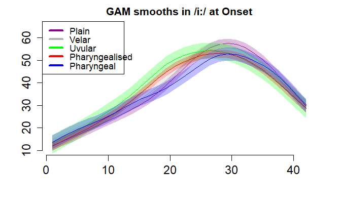

```r
legend("topleft", legend=c("Plain", "Velar", "Uvular","Pharyngealised","Pharyngeal"),
       col=c("darkmagenta","gray70","green","red","blue"), lwd=4)
```

#### 3.6.1.2 Midpoint

```r
plot_smooth(phar.gam.AR, view = "Fan",cond = list(context.ord="plain",vowel.ord="ii",time=2),col="darkmagenta",ylim = c(10,65),ylab="",xlab="",
            main="GAM smooths in /i:/ at Mid",hide.label=T,cex.axis=1.3,rm.ranef=T)
```

```
Summary:
    * context.ord : factor; set to the value(s): plain.
    * vowel.ord : factor; set to the value(s): ii.
    * Fan : numeric predictor; with 30 values ranging from 1.000000 to 42.000000.
    * time : numeric predictor; set to the value(s): 2.
    * word : factor; set to the value(s): 2aa3aa. (Might be canceled as random effect, check below.)
    * NOTE : The following random effects columns are canceled: s(Fan,word),s(time,word)
```

```r
plot_smooth(phar.gam.AR, view = "Fan",cond = list(context.ord="velar",vowel.ord="ii",time=2),col="gray70",add=TRUE,ylim = c(10,65),hide.label=T,cex.axis=1.3,rm.ranef=T)
```

```
Summary:
    * context.ord : factor; set to the value(s): velar.
    * vowel.ord : factor; set to the value(s): ii.
    * Fan : numeric predictor; with 30 values ranging from 1.000000 to 42.000000.
    * time : numeric predictor; set to the value(s): 2.
    * word : factor; set to the value(s): 2aa3aa. (Might be canceled as random effect, check below.)
    * NOTE : The following random effects columns are canceled: s(Fan,word),s(time,word)
```

```r
plot_smooth(phar.gam.AR, view = "Fan",cond = list(context.ord="uvular",vowel.ord="ii",time=2),col="green",add=TRUE,ylim = c(10,65),hide.label=T,cex.axis=1.3,rm.ranef=T)
```

```
Summary:
    * context.ord : factor; set to the value(s): uvular.
    * vowel.ord : factor; set to the value(s): ii.
    * Fan : numeric predictor; with 30 values ranging from 1.000000 to 42.000000.
    * time : numeric predictor; set to the value(s): 2.
    * word : factor; set to the value(s): 2aa3aa. (Might be canceled as random effect, check below.)
    * NOTE : The following random effects columns are canceled: s(Fan,word),s(time,word)
```

```r
plot_smooth(phar.gam.AR, view = "Fan",cond = list(context.ord="pharyngealised",vowel.ord="ii",time=2),col="red",add=TRUE,ylim = c(10,65),hide.label=T,cex.axis=1.3,rm.ranef=T)
```

```
Summary:
    * context.ord : factor; set to the value(s): pharyngealised.
    * vowel.ord : factor; set to the value(s): ii.
    * Fan : numeric predictor; with 30 values ranging from 1.000000 to 42.000000.
    * time : numeric predictor; set to the value(s): 2.
    * word : factor; set to the value(s): 2aa3aa. (Might be canceled as random effect, check below.)
    * NOTE : The following random effects columns are canceled: s(Fan,word),s(time,word)
```

```r
plot_smooth(phar.gam.AR, view = "Fan",cond = list(context.ord="pharyngeal",vowel.ord="ii",time=2),col="blue",add=TRUE,ylim = c(10,65),hide.label=T,cex.axis=1.3,rm.ranef=T)
```

```
Summary:
    * context.ord : factor; set to the value(s): pharyngeal.
    * vowel.ord : factor; set to the value(s): ii.
    * Fan : numeric predictor; with 30 values ranging from 1.000000 to 42.000000.
    * time : numeric predictor; set to the value(s): 2.
    * word : factor; set to the value(s): 2aa3aa. (Might be canceled as random effect, check below.)
    * NOTE : The following random effects columns are canceled: s(Fan,word),s(time,word)
```

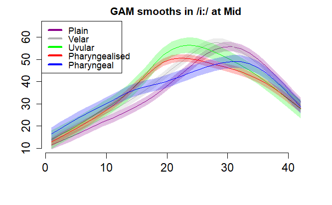

```r
legend("topleft", legend=c("Plain", "Velar", "Uvular","Pharyngealised","Pharyngeal"),
       col=c("darkmagenta","gray70","green","red","blue"), lwd=4)
```

#### 3.6.1.3 Offset

```r
plot_smooth(phar.gam.AR, view = "Fan",cond = list(context.ord="plain",vowel.ord="ii",time=3),col="darkmagenta",ylim = c(10,65),ylab="",xlab="",
            main="GAM smooths in /i:/ at Offset",hide.label=T,cex.axis=1.3,rm.ranef=T)
```

```
Summary:
    * context.ord : factor; set to the value(s): plain.
    * vowel.ord : factor; set to the value(s): ii.
    * Fan : numeric predictor; with 30 values ranging from 1.000000 to 42.000000.
    * time : numeric predictor; set to the value(s): 3.
    * word : factor; set to the value(s): 2aa3aa. (Might be canceled as random effect, check below.)
    * NOTE : The following random effects columns are canceled: s(Fan,word),s(time,word)
```

```r
plot_smooth(phar.gam.AR, view = "Fan",cond = list(context.ord="velar",vowel.ord="ii",time=3),col="gray70",add=TRUE,ylim = c(10,65),hide.label=T,cex.axis=1.3,rm.ranef=T)
```

```
Summary:
    * context.ord : factor; set to the value(s): velar.
    * vowel.ord : factor; set to the value(s): ii.
    * Fan : numeric predictor; with 30 values ranging from 1.000000 to 42.000000.
    * time : numeric predictor; set to the value(s): 3.
    * word : factor; set to the value(s): 2aa3aa. (Might be canceled as random effect, check below.)
    * NOTE : The following random effects columns are canceled: s(Fan,word),s(time,word)
```

```r
plot_smooth(phar.gam.AR, view = "Fan",cond = list(context.ord="uvular",vowel.ord="ii",time=3),col="green",add=TRUE,ylim = c(10,65),hide.label=T,cex.axis=1.3,rm.ranef=T)
```

```
Summary:
    * context.ord : factor; set to the value(s): uvular.
    * vowel.ord : factor; set to the value(s): ii.
    * Fan : numeric predictor; with 30 values ranging from 1.000000 to 42.000000.
    * time : numeric predictor; set to the value(s): 3.
    * word : factor; set to the value(s): 2aa3aa. (Might be canceled as random effect, check below.)
    * NOTE : The following random effects columns are canceled: s(Fan,word),s(time,word)
```

```r
plot_smooth(phar.gam.AR, view = "Fan",cond = list(context.ord="pharyngealised",vowel.ord="ii",time=3),col="red",add=TRUE,ylim = c(10,65),hide.label=T,cex.axis=1.3,rm.ranef=T)
```

```
Summary:
    * context.ord : factor; set to the value(s): pharyngealised.
    * vowel.ord : factor; set to the value(s): ii.
    * Fan : numeric predictor; with 30 values ranging from 1.000000 to 42.000000.
    * time : numeric predictor; set to the value(s): 3.
    * word : factor; set to the value(s): 2aa3aa. (Might be canceled as random effect, check below.)
    * NOTE : The following random effects columns are canceled: s(Fan,word),s(time,word)
```

```r
plot_smooth(phar.gam.AR, view = "Fan",cond = list(context.ord="pharyngeal",vowel.ord="ii",time=3),col="blue",add=TRUE,ylim = c(10,65),hide.label=T,cex.axis=1.3,rm.ranef=T)
```

```
Summary:
    * context.ord : factor; set to the value(s): pharyngeal.
    * vowel.ord : factor; set to the value(s): ii.
    * Fan : numeric predictor; with 30 values ranging from 1.000000 to 42.000000.
    * time : numeric predictor; set to the value(s): 3.
    * word : factor; set to the value(s): 2aa3aa. (Might be canceled as random effect, check below.)
    * NOTE : The following random effects columns are canceled: s(Fan,word),s(time,word)
```

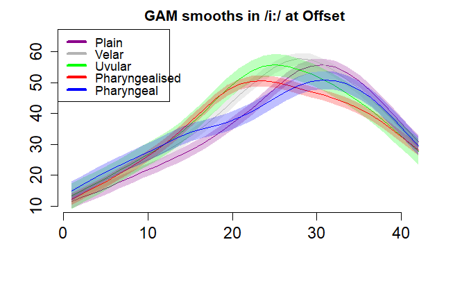

```r
legend("topleft", legend=c("Plain", "Velar", "Uvular","Pharyngealised","Pharyngeal"),
       col=c("darkmagenta","gray70","green","red","blue"), lwd=4)
```

### 3.6.2 Vowel /a:/

#### 3.6.2.1 Onset

```r
plot_smooth(phar.gam.AR, view = "Fan",cond = list(context.ord="plain",vowel.ord="aa",time=1),col="darkmagenta",ylim = c(10,65),ylab="",xlab="",
            main="GAM smooths in /a:/ at Onset",hide.label=T,cex.axis=1.3,rm.ranef=T)
```

```
Summary:
    * context.ord : factor; set to the value(s): plain.
    * vowel.ord : factor; set to the value(s): aa.
    * Fan : numeric predictor; with 30 values ranging from 1.000000 to 42.000000.
    * time : numeric predictor; set to the value(s): 1.
    * word : factor; set to the value(s): 2aa3aa. (Might be canceled as random effect, check below.)
    * NOTE : The following random effects columns are canceled: s(Fan,word),s(time,word)
```

```r
plot_smooth(phar.gam.AR, view = "Fan",cond = list(context.ord="velar",vowel.ord="aa",time=1),col="gray70",add=TRUE,ylim = c(10,65),hide.label=T,cex.axis=1.3,rm.ranef=T)
```

```
Summary:
    * context.ord : factor; set to the value(s): velar.
    * vowel.ord : factor; set to the value(s): aa.
    * Fan : numeric predictor; with 30 values ranging from 1.000000 to 42.000000.
    * time : numeric predictor; set to the value(s): 1.
    * word : factor; set to the value(s): 2aa3aa. (Might be canceled as random effect, check below.)
    * NOTE : The following random effects columns are canceled: s(Fan,word),s(time,word)
```

```r
plot_smooth(phar.gam.AR, view = "Fan",cond = list(context.ord="uvular",vowel.ord="aa",time=1),col="green",add=TRUE,ylim = c(10,65),hide.label=T,cex.axis=1.3,rm.ranef=T)
```

```
Summary:
    * context.ord : factor; set to the value(s): uvular.
    * vowel.ord : factor; set to the value(s): aa.
    * Fan : numeric predictor; with 30 values ranging from 1.000000 to 42.000000.
    * time : numeric predictor; set to the value(s): 1.
    * word : factor; set to the value(s): 2aa3aa. (Might be canceled as random effect, check below.)
    * NOTE : The following random effects columns are canceled: s(Fan,word),s(time,word)
```

```r
plot_smooth(phar.gam.AR, view = "Fan",cond = list(context.ord="pharyngealised",vowel.ord="aa",time=1),col="red",add=TRUE,ylim = c(10,65),hide.label=T,cex.axis=1.3,rm.ranef=T)
```

```
Summary:
    * context.ord : factor; set to the value(s): pharyngealised.
    * vowel.ord : factor; set to the value(s): aa.
    * Fan : numeric predictor; with 30 values ranging from 1.000000 to 42.000000.
    * time : numeric predictor; set to the value(s): 1.
    * word : factor; set to the value(s): 2aa3aa. (Might be canceled as random effect, check below.)
    * NOTE : The following random effects columns are canceled: s(Fan,word),s(time,word)
```

```r
plot_smooth(phar.gam.AR, view = "Fan",cond = list(context.ord="pharyngeal",vowel.ord="aa",time=1),col="blue",add=TRUE,ylim = c(10,65),hide.label=T,cex.axis=1.3,rm.ranef=T)
```

```
Summary:
    * context.ord : factor; set to the value(s): pharyngeal.
    * vowel.ord : factor; set to the value(s): aa.
    * Fan : numeric predictor; with 30 values ranging from 1.000000 to 42.000000.
    * time : numeric predictor; set to the value(s): 1.
    * word : factor; set to the value(s): 2aa3aa. (Might be canceled as random effect, check below.)
    * NOTE : The following random effects columns are canceled: s(Fan,word),s(time,word)
```

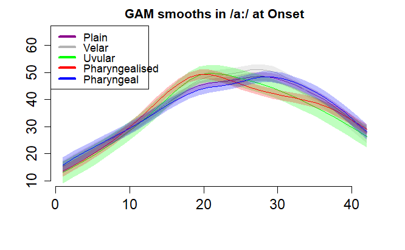

```r
legend("topleft", legend=c("Plain", "Velar", "Uvular","Pharyngealised","Pharyngeal"),
       col=c("darkmagenta","gray70","green","red","blue"), lwd=4)
```

#### 3.6.2.2 Midpoint

```r
plot_smooth(phar.gam.AR, view = "Fan",cond = list(context.ord="plain",vowel.ord="aa",time=2),col="darkmagenta",ylim = c(10,65),ylab="",xlab="",
            main="GAM smooths in /a:/ at Mid",hide.label=T,cex.axis=1.3,rm.ranef=T)
```

```
Summary:
    * context.ord : factor; set to the value(s): plain.
    * vowel.ord : factor; set to the value(s): aa.
    * Fan : numeric predictor; with 30 values ranging from 1.000000 to 42.000000.
    * time : numeric predictor; set to the value(s): 2.
    * word : factor; set to the value(s): 2aa3aa. (Might be canceled as random effect, check below.)
    * NOTE : The following random effects columns are canceled: s(Fan,word),s(time,word)
```

```r
plot_smooth(phar.gam.AR, view = "Fan",cond = list(context.ord="velar",vowel.ord="aa",time=2),col="gray70",add=TRUE,ylim = c(10,65),hide.label=T,cex.axis=1.3,rm.ranef=T)
```

```
Summary:
    * context.ord : factor; set to the value(s): velar.
    * vowel.ord : factor; set to the value(s): aa.
    * Fan : numeric predictor; with 30 values ranging from 1.000000 to 42.000000.
    * time : numeric predictor; set to the value(s): 2.
    * word : factor; set to the value(s): 2aa3aa. (Might be canceled as random effect, check below.)
    * NOTE : The following random effects columns are canceled: s(Fan,word),s(time,word)
```

```r
plot_smooth(phar.gam.AR, view = "Fan",cond = list(context.ord="uvular",vowel.ord="aa",time=2),col="green",add=TRUE,ylim = c(10,65),hide.label=T,cex.axis=1.3,rm.ranef=T)
```

```
Summary:
    * context.ord : factor; set to the value(s): uvular.
    * vowel.ord : factor; set to the value(s): aa.
    * Fan : numeric predictor; with 30 values ranging from 1.000000 to 42.000000.
    * time : numeric predictor; set to the value(s): 2.
    * word : factor; set to the value(s): 2aa3aa. (Might be canceled as random effect, check below.)
    * NOTE : The following random effects columns are canceled: s(Fan,word),s(time,word)
```

```r
plot_smooth(phar.gam.AR, view = "Fan",cond = list(context.ord="pharyngealised",vowel.ord="aa",time=2),col="red",add=TRUE,ylim = c(10,65),hide.label=T,cex.axis=1.3,rm.ranef=T)
```

```
Summary:
    * context.ord : factor; set to the value(s): pharyngealised.
    * vowel.ord : factor; set to the value(s): aa.
    * Fan : numeric predictor; with 30 values ranging from 1.000000 to 42.000000.
    * time : numeric predictor; set to the value(s): 2.
    * word : factor; set to the value(s): 2aa3aa. (Might be canceled as random effect, check below.)
    * NOTE : The following random effects columns are canceled: s(Fan,word),s(time,word)
```

```r
plot_smooth(phar.gam.AR, view = "Fan",cond = list(context.ord="pharyngeal",vowel.ord="aa",time=2),col="blue",add=TRUE,ylim = c(10,65),hide.label=T,cex.axis=1.3,rm.ranef=T)
```

```
Summary:
    * context.ord : factor; set to the value(s): pharyngeal.
    * vowel.ord : factor; set to the value(s): aa.
    * Fan : numeric predictor; with 30 values ranging from 1.000000 to 42.000000.
    * time : numeric predictor; set to the value(s): 2.
    * word : factor; set to the value(s): 2aa3aa. (Might be canceled as random effect, check below.)
    * NOTE : The following random effects columns are canceled: s(Fan,word),s(time,word)
```

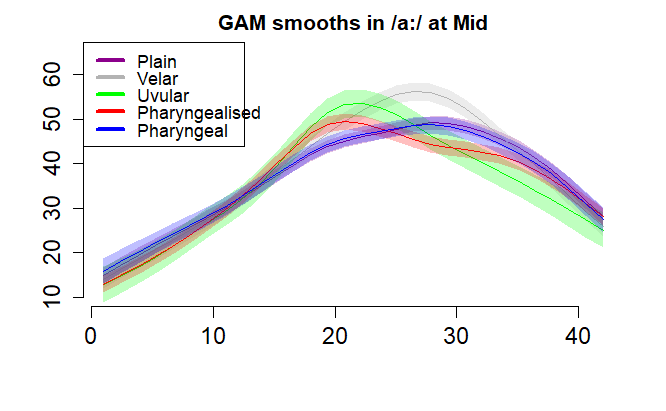

```r
legend("topleft", legend=c("Plain", "Velar", "Uvular","Pharyngealised","Pharyngeal"),
       col=c("darkmagenta","gray70","green","red","blue"), lwd=4)
```

#### 3.6.2.3 Offset

```r
plot_smooth(phar.gam.AR, view = "Fan",cond = list(context.ord="plain",vowel.ord="aa",time=3),col="darkmagenta",ylim = c(10,65),ylab="",xlab="",
            main="GAM smooths in /a:/ at Offset",hide.label=T,cex.axis=1.3,rm.ranef=T)
```

```
Summary:
    * context.ord : factor; set to the value(s): plain.
    * vowel.ord : factor; set to the value(s): aa.
    * Fan : numeric predictor; with 30 values ranging from 1.000000 to 42.000000.
    * time : numeric predictor; set to the value(s): 3.
    * word : factor; set to the value(s): 2aa3aa. (Might be canceled as random effect, check below.)
    * NOTE : The following random effects columns are canceled: s(Fan,word),s(time,word)
```

```r
plot_smooth(phar.gam.AR, view = "Fan",cond = list(context.ord="velar",vowel.ord="aa",time=3),col="gray70",add=TRUE,ylim = c(10,65),hide.label=T,cex.axis=1.3,rm.ranef=T)
```

```
Summary:
    * context.ord : factor; set to the value(s): velar.
    * vowel.ord : factor; set to the value(s): aa.
    * Fan : numeric predictor; with 30 values ranging from 1.000000 to 42.000000.
    * time : numeric predictor; set to the value(s): 3.
    * word : factor; set to the value(s): 2aa3aa. (Might be canceled as random effect, check below.)
    * NOTE : The following random effects columns are canceled: s(Fan,word),s(time,word)
```

```r
plot_smooth(phar.gam.AR, view = "Fan",cond = list(context.ord="uvular",vowel.ord="aa",time=3),col="green",add=TRUE,ylim = c(10,65),hide.label=T,cex.axis=1.3,rm.ranef=T)
```

```
Summary:
    * context.ord : factor; set to the value(s): uvular.
    * vowel.ord : factor; set to the value(s): aa.
    * Fan : numeric predictor; with 30 values ranging from 1.000000 to 42.000000.
    * time : numeric predictor; set to the value(s): 3.
    * word : factor; set to the value(s): 2aa3aa. (Might be canceled as random effect, check below.)
    * NOTE : The following random effects columns are canceled: s(Fan,word),s(time,word)
```

```r
plot_smooth(phar.gam.AR, view = "Fan",cond = list(context.ord="pharyngealised",vowel.ord="aa",time=3),col="red",add=TRUE,ylim = c(10,65),hide.label=T,cex.axis=1.3,rm.ranef=T)
```

```
Summary:
    * context.ord : factor; set to the value(s): pharyngealised.
    * vowel.ord : factor; set to the value(s): aa.
    * Fan : numeric predictor; with 30 values ranging from 1.000000 to 42.000000.
    * time : numeric predictor; set to the value(s): 3.
    * word : factor; set to the value(s): 2aa3aa. (Might be canceled as random effect, check below.)
    * NOTE : The following random effects columns are canceled: s(Fan,word),s(time,word)
```

```r
plot_smooth(phar.gam.AR, view = "Fan",cond = list(context.ord="pharyngeal",vowel.ord="aa",time=3),col="blue",add=TRUE,ylim = c(10,65),hide.label=T,cex.axis=1.3,rm.ranef=T)
```

```
Summary:
    * context.ord : factor; set to the value(s): pharyngeal.
    * vowel.ord : factor; set to the value(s): aa.
    * Fan : numeric predictor; with 30 values ranging from 1.000000 to 42.000000.
    * time : numeric predictor; set to the value(s): 3.
    * word : factor; set to the value(s): 2aa3aa. (Might be canceled as random effect, check below.)
    * NOTE : The following random effects columns are canceled: s(Fan,word),s(time,word)
```

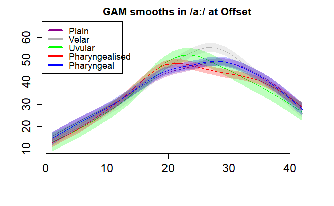

```r
legend("topleft", legend=c("Plain", "Velar", "Uvular","Pharyngealised","Pharyngeal"),
       col=c("darkmagenta","gray70","green","red","blue"), lwd=4)
```

### 3.6.3 Vowel /u:/

#### 3.6.3.1 Onset

```r
plot_smooth(phar.gam.AR, view = "Fan",cond = list(context.ord="plain",vowel.ord="uu",time=1),col="darkmagenta",ylim = c(10,65),ylab="",xlab="",
            main="GAM smooths in /u:/ at Onset",hide.label=T,cex.axis=1.3,rm.ranef=T)
```

```
Summary:
    * context.ord : factor; set to the value(s): plain.
    * vowel.ord : factor; set to the value(s): uu.
    * Fan : numeric predictor; with 30 values ranging from 1.000000 to 42.000000.
    * time : numeric predictor; set to the value(s): 1.
    * word : factor; set to the value(s): 2aa3aa. (Might be canceled as random effect, check below.)
    * NOTE : The following random effects columns are canceled: s(Fan,word),s(time,word)
```

```r
plot_smooth(phar.gam.AR, view = "Fan",cond = list(context.ord="velar",vowel.ord="uu",time=1),col="gray70",add=TRUE,ylim = c(10,65),hide.label=T,cex.axis=1.3,rm.ranef=T)
```

```
Summary:
    * context.ord : factor; set to the value(s): velar.
    * vowel.ord : factor; set to the value(s): uu.
    * Fan : numeric predictor; with 30 values ranging from 1.000000 to 42.000000.
    * time : numeric predictor; set to the value(s): 1.
    * word : factor; set to the value(s): 2aa3aa. (Might be canceled as random effect, check below.)
    * NOTE : The following random effects columns are canceled: s(Fan,word),s(time,word)
```

```r
plot_smooth(phar.gam.AR, view = "Fan",cond = list(context.ord="uvular",vowel.ord="uu",time=1),col="green",add=TRUE,ylim = c(10,65),hide.label=T,cex.axis=1.3,rm.ranef=T)
```

```
Summary:
    * context.ord : factor; set to the value(s): uvular.
    * vowel.ord : factor; set to the value(s): uu.
    * Fan : numeric predictor; with 30 values ranging from 1.000000 to 42.000000.
    * time : numeric predictor; set to the value(s): 1.
    * word : factor; set to the value(s): 2aa3aa. (Might be canceled as random effect, check below.)
    * NOTE : The following random effects columns are canceled: s(Fan,word),s(time,word)
```

```r
plot_smooth(phar.gam.AR, view = "Fan",cond = list(context.ord="pharyngealised",vowel.ord="uu",time=1),col="red",add=TRUE,ylim = c(10,65),hide.label=T,cex.axis=1.3,rm.ranef=T)
```

```
Summary:
    * context.ord : factor; set to the value(s): pharyngealised.
    * vowel.ord : factor; set to the value(s): uu.
    * Fan : numeric predictor; with 30 values ranging from 1.000000 to 42.000000.
    * time : numeric predictor; set to the value(s): 1.
    * word : factor; set to the value(s): 2aa3aa. (Might be canceled as random effect, check below.)
    * NOTE : The following random effects columns are canceled: s(Fan,word),s(time,word)
```

```r
plot_smooth(phar.gam.AR, view = "Fan",cond = list(context.ord="pharyngeal",vowel.ord="uu",time=1),col="blue",add=TRUE,ylim = c(10,65),hide.label=T,cex.axis=1.3,rm.ranef=T)
```

```
Summary:
    * context.ord : factor; set to the value(s): pharyngeal.
    * vowel.ord : factor; set to the value(s): uu.
    * Fan : numeric predictor; with 30 values ranging from 1.000000 to 42.000000.
    * time : numeric predictor; set to the value(s): 1.
    * word : factor; set to the value(s): 2aa3aa. (Might be canceled as random effect, check below.)
    * NOTE : The following random effects columns are canceled: s(Fan,word),s(time,word)
```

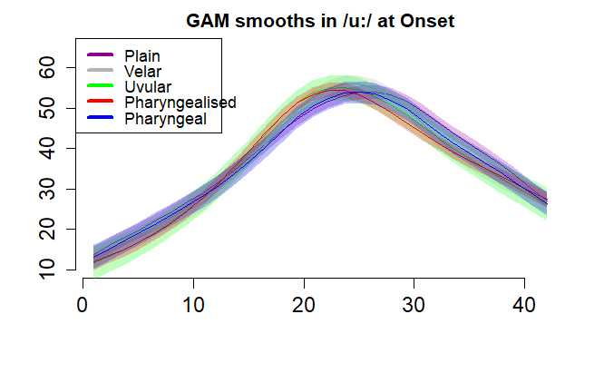

```r
legend("topleft", legend=c("Plain", "Velar", "Uvular","Pharyngealised","Pharyngeal"),
       col=c("darkmagenta","gray70","green","red","blue"), lwd=4)
```

#### 3.6.3.2 Midpoint

```r
plot_smooth(phar.gam.AR, view = "Fan",cond = list(context.ord="plain",vowel.ord="uu",time=2),col="darkmagenta",ylim = c(10,65),ylab="",xlab="",
            main="GAM smooths in /u:/ at Mid",hide.label=T,cex.axis=1.3,rm.ranef=T)
```

```
Summary:
    * context.ord : factor; set to the value(s): plain.
    * vowel.ord : factor; set to the value(s): uu.
    * Fan : numeric predictor; with 30 values ranging from 1.000000 to 42.000000.
    * time : numeric predictor; set to the value(s): 2.
    * word : factor; set to the value(s): 2aa3aa. (Might be canceled as random effect, check below.)
    * NOTE : The following random effects columns are canceled: s(Fan,word),s(time,word)
```

```r
plot_smooth(phar.gam.AR, view = "Fan",cond = list(context.ord="velar",vowel.ord="uu",time=2),col="gray70",add=TRUE,ylim = c(10,65),hide.label=T,cex.axis=1.3,rm.ranef=T)
```

```
Summary:
    * context.ord : factor; set to the value(s): velar.
    * vowel.ord : factor; set to the value(s): uu.
    * Fan : numeric predictor; with 30 values ranging from 1.000000 to 42.000000.
    * time : numeric predictor; set to the value(s): 2.
    * word : factor; set to the value(s): 2aa3aa. (Might be canceled as random effect, check below.)
    * NOTE : The following random effects columns are canceled: s(Fan,word),s(time,word)
```

```r
plot_smooth(phar.gam.AR, view = "Fan",cond = list(context.ord="uvular",vowel.ord="uu",time=2),col="green",add=TRUE,ylim = c(10,65),hide.label=T,cex.axis=1.3,rm.ranef=T)
```

```
Summary:
    * context.ord : factor; set to the value(s): uvular.
    * vowel.ord : factor; set to the value(s): uu.
    * Fan : numeric predictor; with 30 values ranging from 1.000000 to 42.000000.
    * time : numeric predictor; set to the value(s): 2.
    * word : factor; set to the value(s): 2aa3aa. (Might be canceled as random effect, check below.)
    * NOTE : The following random effects columns are canceled: s(Fan,word),s(time,word)
```

```r
plot_smooth(phar.gam.AR, view = "Fan",cond = list(context.ord="pharyngealised",vowel.ord="uu",time=2),col="red",add=TRUE,ylim = c(10,65),hide.label=T,cex.axis=1.3,rm.ranef=T)
```

```
Summary:
    * context.ord : factor; set to the value(s): pharyngealised.
    * vowel.ord : factor; set to the value(s): uu.
    * Fan : numeric predictor; with 30 values ranging from 1.000000 to 42.000000.
    * time : numeric predictor; set to the value(s): 2.
    * word : factor; set to the value(s): 2aa3aa. (Might be canceled as random effect, check below.)
    * NOTE : The following random effects columns are canceled: s(Fan,word),s(time,word)
```

```r
plot_smooth(phar.gam.AR, view = "Fan",cond = list(context.ord="pharyngeal",vowel.ord="uu",time=2),col="blue",add=TRUE,ylim = c(10,65),hide.label=T,cex.axis=1.3,rm.ranef=T)
```

```
Summary:
    * context.ord : factor; set to the value(s): pharyngeal.
    * vowel.ord : factor; set to the value(s): uu.
    * Fan : numeric predictor; with 30 values ranging from 1.000000 to 42.000000.
    * time : numeric predictor; set to the value(s): 2.
    * word : factor; set to the value(s): 2aa3aa. (Might be canceled as random effect, check below.)
    * NOTE : The following random effects columns are canceled: s(Fan,word),s(time,word)
```

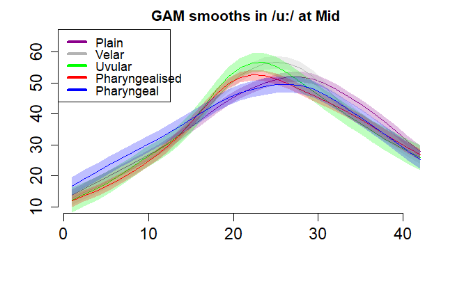

```r
legend("topleft", legend=c("Plain", "Velar", "Uvular","Pharyngealised","Pharyngeal"),
       col=c("darkmagenta","gray70","green","red","blue"), lwd=4)
```

#### 3.6.3.3 Offset

```r
plot_smooth(phar.gam.AR, view = "Fan",cond = list(context.ord="plain",vowel.ord="uu",time=3),col="darkmagenta",ylim = c(10,65),ylab="",xlab="",
            main="GAM smooths in /u:/ at Offset",hide.label=T,cex.axis=1.3,rm.ranef=T)
```

```
Summary:
    * context.ord : factor; set to the value(s): plain.
    * vowel.ord : factor; set to the value(s): uu.
    * Fan : numeric predictor; with 30 values ranging from 1.000000 to 42.000000.
    * time : numeric predictor; set to the value(s): 3.
    * word : factor; set to the value(s): 2aa3aa. (Might be canceled as random effect, check below.)
    * NOTE : The following random effects columns are canceled: s(Fan,word),s(time,word)
```

```r
plot_smooth(phar.gam.AR, view = "Fan",cond = list(context.ord="velar",vowel.ord="uu",time=3),col="gray70",add=TRUE,ylim = c(10,65),hide.label=T,cex.axis=1.3,rm.ranef=T)
```

```
Summary:
    * context.ord : factor; set to the value(s): velar.
    * vowel.ord : factor; set to the value(s): uu.
    * Fan : numeric predictor; with 30 values ranging from 1.000000 to 42.000000.
    * time : numeric predictor; set to the value(s): 3.
    * word : factor; set to the value(s): 2aa3aa. (Might be canceled as random effect, check below.)
    * NOTE : The following random effects columns are canceled: s(Fan,word),s(time,word)
```

```r
plot_smooth(phar.gam.AR, view = "Fan",cond = list(context.ord="uvular",vowel.ord="uu",time=3),col="green",add=TRUE,ylim = c(10,65),hide.label=T,cex.axis=1.3,rm.ranef=T)
```

```
Summary:
    * context.ord : factor; set to the value(s): uvular.
    * vowel.ord : factor; set to the value(s): uu.
    * Fan : numeric predictor; with 30 values ranging from 1.000000 to 42.000000.
    * time : numeric predictor; set to the value(s): 3.
    * word : factor; set to the value(s): 2aa3aa. (Might be canceled as random effect, check below.)
    * NOTE : The following random effects columns are canceled: s(Fan,word),s(time,word)
```

```r
plot_smooth(phar.gam.AR, view = "Fan",cond = list(context.ord="pharyngealised",vowel.ord="uu",time=3),col="red",add=TRUE,ylim = c(10,65),hide.label=T,cex.axis=1.3,rm.ranef=T)
```

```
Summary:
    * context.ord : factor; set to the value(s): pharyngealised.
    * vowel.ord : factor; set to the value(s): uu.
    * Fan : numeric predictor; with 30 values ranging from 1.000000 to 42.000000.
    * time : numeric predictor; set to the value(s): 3.
    * word : factor; set to the value(s): 2aa3aa. (Might be canceled as random effect, check below.)
    * NOTE : The following random effects columns are canceled: s(Fan,word),s(time,word)
```

```r
plot_smooth(phar.gam.AR, view = "Fan",cond = list(context.ord="pharyngeal",vowel.ord="uu",time=3),col="blue",add=TRUE,ylim = c(10,65),hide.label=T,cex.axis=1.3,rm.ranef=T)
```

```
Summary:
    * context.ord : factor; set to the value(s): pharyngeal.
    * vowel.ord : factor; set to the value(s): uu.
    * Fan : numeric predictor; with 30 values ranging from 1.000000 to 42.000000.
    * time : numeric predictor; set to the value(s): 3.
    * word : factor; set to the value(s): 2aa3aa. (Might be canceled as random effect, check below.)
    * NOTE : The following random effects columns are canceled: s(Fan,word),s(time,word)
```

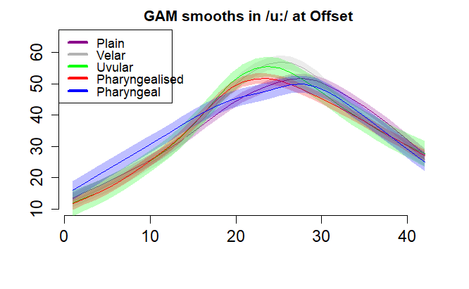

```r
legend("topleft", legend=c("Plain", "Velar", "Uvular","Pharyngealised","Pharyngeal"),
       col=c("darkmagenta","gray70","green","red","blue"), lwd=4)
```